# Activity monitoring data analysis

haoeric

9 July, 2014

This is an R Markdown document for my solution to the assignment 1 of course **Reproduciable Research** on Coursera

## Loading and preprocessing the data

Let’s take a first look of the dataset

```r
data_path = "/Users/chenhao/GitProject/RepData_PeerAssessment1/"
activity_data = read.csv(paste(data_path,"activity.csv", sep=""),
                         stringsAsFactors = F)
# format the data and transform NA to 0
activity_data$date <- as.Date(activity_data$date, "%Y-%m-%d")
#activity_data$steps[is.na(activity_data$steps)] = 0
head(activity_data)
```

```
##   steps       date interval
## 1    NA 2012-10-01        0
## 2    NA 2012-10-01        5
## 3    NA 2012-10-01       10
## 4    NA 2012-10-01       15
## 5    NA 2012-10-01       20
## 6    NA 2012-10-01       25
```

## What is mean total number of steps taken per day?

split the data by date and do analysis of steps on date

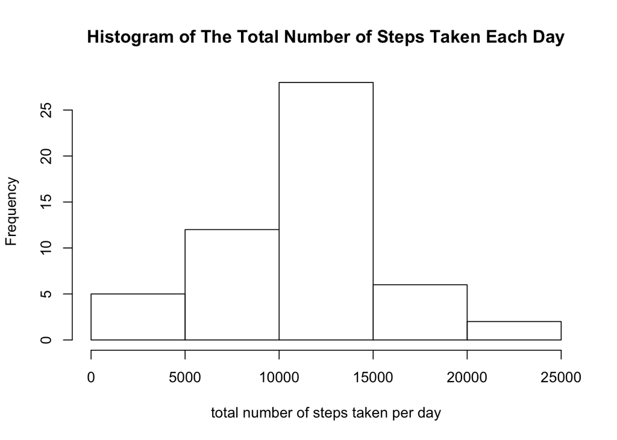

```r
# organize the date by days
sum_steps_per_day <- aggregate(steps ~ date, data = activity_data, sum)
mean_steps = as.integer(mean(sum_steps_per_day$step, na.rm = T))
median_steps = as.integer(median(sum_steps_per_day$step, na.rm = T))
# plot the histogram of the total number of steps taken each day
hist(sum_steps_per_day$steps,
     main="Histogram of The Total Number of Steps Taken Each Day",
     xlab = "total number of steps taken per day"
     )
```

The mean total number of steps taken per day was 10766 , and The median total number of steps taken per day was 10765.

## What is the average daily activity pattern?

split the data by interval and do analysis of steps on interval

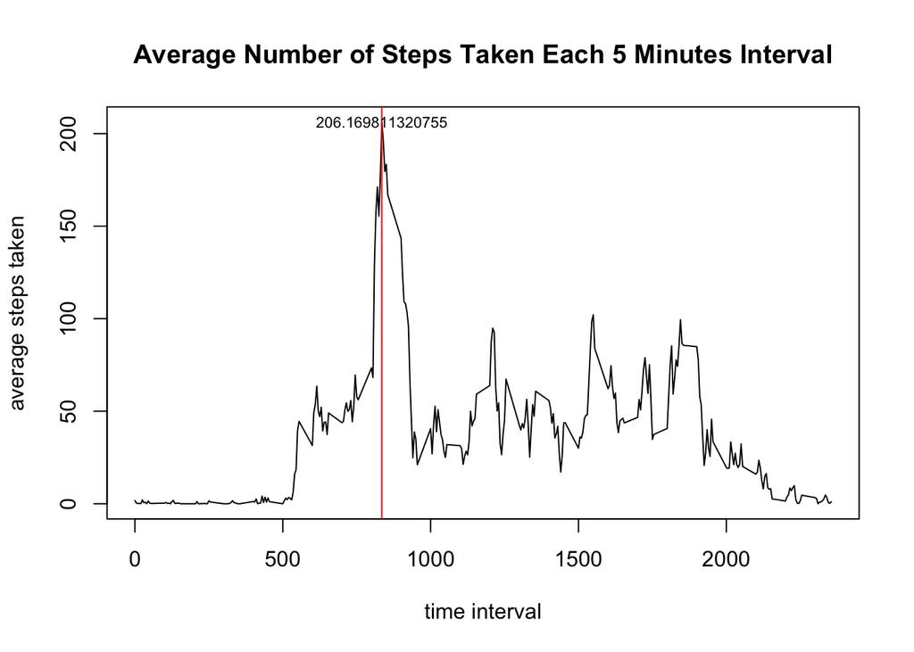

```r
# organize the data by daily time series
daily_steps <- aggregate(steps ~ interval, data = activity_data, mean)
plot(daily_steps$interval,
     daily_steps$steps,
     type = "l",
     main = "Average Number of Steps Taken Each 5 Minutes Interval",
     xlab = "time interval",
     ylab = "average steps taken")

abline(v = daily_steps[daily_steps$steps == max(daily_steps$steps), 1],
       col = "red")
text(x = daily_steps[daily_steps$steps == max(daily_steps$steps),1],
     y = max(daily_steps$steps),
     labels= max(daily_steps$steps),
     cex= 0.7, offset = 10)
```

```r
maximun_activity_pattern  = daily_steps[daily_steps$steps == max(daily_steps$steps),1]
```

## Imputing missing values

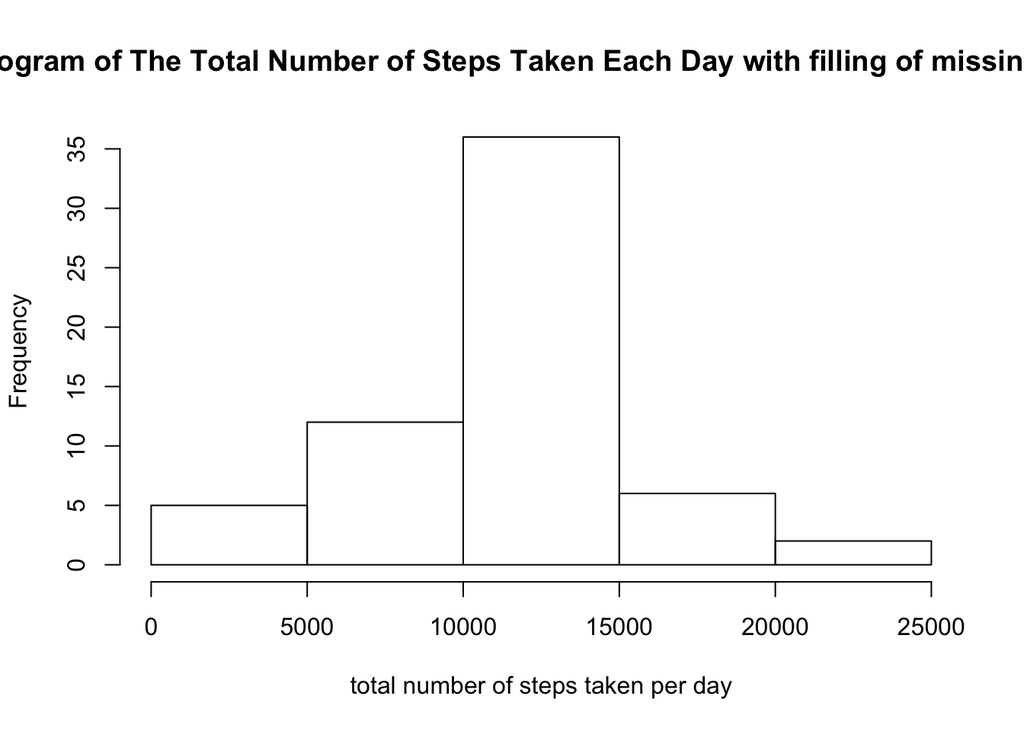

```r
# check the number of NA values
NA_num = sum(is.na(activity_data$steps))

# fill the missing values with mean steps of that interval
new_activity_data <- activity_data
for (i in 1:length(new_activity_data$steps)) {
       if (is.na(new_activity_data$steps[i])) {
               mean_activity <- daily_steps[daily_steps$interval == new_activity_data$interval[i], 2]
               new_activity_data$steps[i] <- mean_activity }
}

# Make a histogram of the total number of steps taken each day
new_sum_steps_per_day <- aggregate(steps ~ date, data = new_activity_data, sum)
new_mean_steps = as.integer(mean(new_sum_steps_per_day$step, na.rm = T))
new_median_steps = as.integer(median(new_sum_steps_per_day$step, na.rm = T))
# plot the histogram of the total number of steps taken each day
hist(new_sum_steps_per_day$steps,
     main="Histogram of The Total Number of Steps Taken Each Day with filling of missing values",
     xlab = "total number of steps taken per day"
     )
```

After repalcing 2304 missing values with mean activity of that interval, The mean total number of steps taken per day was 10766 , and The median total number of steps taken per day was 10766. So we find that the mean value remain the same while the median increased a little.

## Are there differences in activity patterns between weekdays and weekends?

Let’s split the data by week_label and time interval, then calculate the mean steps for each combine of weeklabel and time interval, using lattice to give a plot to visually show the answer.

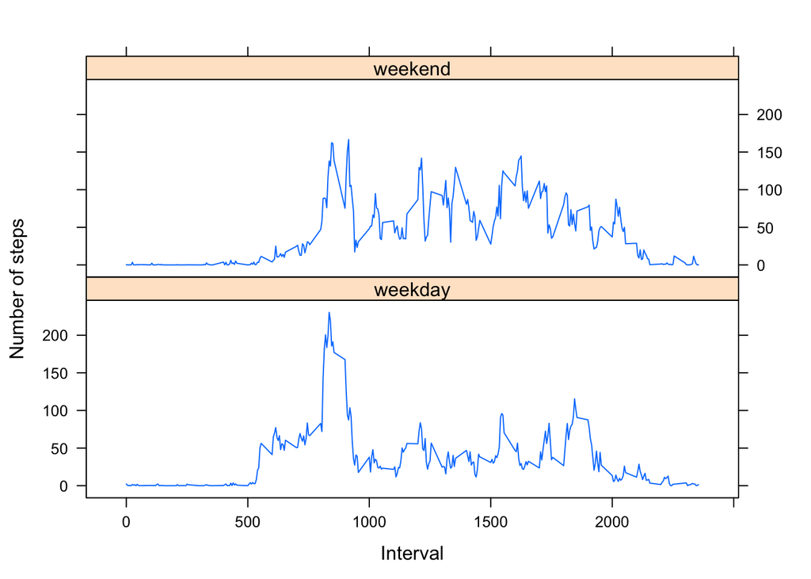

```r
weekdays = c("Monday", "Tuesday", "Wednesday", "Thursday", "Friday")
weekends = c("Saturday", "Sunday")

# add week labels to the dataset
week_label = vector()
new_activity_data$date <- weekdays(new_activity_data$date)
for (i in 1:length(new_activity_data$date)){
        if (new_activity_data$date[i] %in% weekdays){
                week_label = c(week_label, "weekday")  }
        else{
                week_label = c(week_label, "weekend")  }
}
new_activity_data <- transform( new_activity_data, week_labels = week_label)

# split the data by week label and interval then calcualte the mean steps, and plot
mean_steps_per_interval <- aggregate(steps ~ interval + week_labels,
                                     data = new_activity_data, mean)
library(lattice)
xyplot(steps ~ interval|week_labels,
       data = mean_steps_per_interval,
       type = "l",
       xlab = "Interval",
       ylab = "Number of steps",
       layout=c(1,2))
```

We can see that people get more activity on weekends, aha, due to more avaliable time.